```python
import numpy as np
import pandas as pd


#Data Reader from Internet
#pip install pandas-datareader

import matplotlib.pyplot as plt
import seaborn as sns

#visualization inside Jupyter Notebook
%matplotlib inline

#display image in Jupyter Notebook
from IPython.display import Image

###################
# Interative plots
import plotly.graph_objs as go
from plotly.offline import download_plotlyjs, init_notebook_mode, plot, iplot

# get version
from plotly import __version__
#print(__version__)

import cufflinks as cf

# For Notebooks
init_notebook_mode(connected=True)
# For offline use
cf.go_offline()

#[[Plotly "after May 2020"
# + pip install chart-studio
#import chart-studio.plotly as py

###################
# Machine Learning (pip install scikit-learn)
#from sklearn.la_famille_de_modeles import le_modele

from sklearn.model_selection import train_test_split

from sklearn.linear_model import LinearRegression
from sklearn.linear_model import LogisticRegression

from sklearn.preprocessing import StandardScaler
from sklearn.neighbors import KNeighborsClassifier

from sklearn.tree import DecisionTreeClassifier

from sklearn.ensemble import RandomForestClassifier

from sklearn.svm import SVC

##try a bunch of combinations and see what works best!
from sklearn.model_selection import GridSearchCV

from sklearn.cluster import KMeans

from sklearn.decomposition import PCA

from sklearn.metrics import classification_report, confusion_matrix
#from sklearn.metrics import confusion_matrix


#from sklearn.datasets import load_boston #deprecated
# BUT other available (load_breast_cancer, load....)


###################
# NLP - Natural Language Processing (pip install nltk)
import nltk # Natural Language Toolkit
import string
from nltk.corpus import stopwords
from sklearn.feature_extraction.text import CountVectorizer
from sklearn.feature_extraction.text import TfidfTransformer
from sklearn.naive_bayes import MultinomialNB


###################
# PIPELINE
from sklearn.pipeline import Pipeline


###################
# Artificial Neural Networks (ANN) (pip install tensorflow)
```

# **NLP** - Natural Language Processing

Simple Example:

- You have 2 documents:
  - “Blue House”
  - “Red House”
- Featurize based on word count:
  - “Blue House” -> (red,blue,house) -> (0,1,1)
  - “Red House” -> (red,blue,house) -> (1,0,1)

A document represented as a vector of word counts is called a “Bag of Words” * “Blue House” -> (red,blue,house) -> (0,1,1) * “Red House” -> (red,blue,house) -> (1,0,1)

You can use cosine similarity on the vectors made to determine similarity:

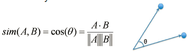

We can improve on Bag of Words by adjusting word counts based on their frequency in corpus (the group of all the documents)

We can use TF-IDF (Term Frequency - Inverse Document Frequency)

- **Term Frequency** - Importance of the term within that

document * TF(d,t) = Number of occurrences of term t in document d

```
Measures how frequently a term occurs in a document.
Since every document is different in length, it is possible that a term would appear much more times in long documents than shorter ones.
Thus, the term frequency is often divided by the document length (aka. the total number of terms in the document) as a way of normalization:

*TF(t) = (Number of times term t appears in a document) / (Total number of terms in the document).*
```

- **Inverse Document Frequency** - Importance of the term in the

corpus

```
Measures how important a term is. While computing TF, all terms are considered equally important. However it is known that certain terms, such as "is", "of", and "that", may appear a lot of times but have little importance. Thus we need to weigh down the frequent terms while scale up the rare ones, by computing the
following:

* IDF(t) = log_e(D/t) where
     * D = total number of documents
     * t = number of documents with the term
```

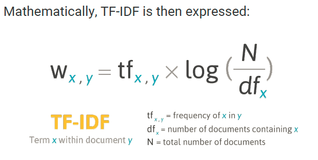

**Example:**

Consider a document containing 100 words wherein the word cat appears 3 times.

The term frequency (i.e., tf) for cat is then (3 / 100) = 0.03.

Now, assume we have 10 million documents and the word cat appears in one thousand of these. Then, the inverse document frequency (i.e., idf) is calculated as log(10,000,000 / 1,000) = 4.

Thus, the Tf-idf weight is the product of these quantities: 0.03 * 4 = 0.12.

```python
import pandas as pd

# load SMS datas
messages = [line.rstrip() for line
            in open('datas/SMSSpamCollection')]

#OR load with usual panda's read_csv
messages = pd.read_csv('datas/SMSSpamCollection',
                       sep='\t',
                       names=["label", "message"])

#add column with message's length
messages['length'] = messages['message'].apply(len)

messages.head()
```

|  | label | message | length |
| --- | --- | --- | --- |
| 0 | ham | Go until jurong point, crazy.. Available only ... | 111 |
| 1 | ham | Ok lar... Joking wif u oni... | 29 |
| 2 | spam | Free entry in 2 a wkly comp to win FA Cup fina... | 155 |
| 3 | ham | U dun say so early hor... U c already then say... | 49 |
| 4 | ham | Nah I don't think he goes to usf, he lives aro... | 61 |

## Text Pre-processing

Our main issue with our data is that it is all in text format (strings). The classification algorithms that we've learned about so far will need some sort of numerical feature vector in order to perform the classification task. There are actually many methods to convert a corpus to a vector format. The simplest is the the [bag-of-words](http://en.wikipedia.org/wiki/Bag-of-words_model) approach, where each unique word in a text will be represented by one number.

In this section we'll convert the raw messages (sequence of characters) into vectors (sequences of numbers).

As a first step, let's write a function that will split a message into its individual words and return a list. We'll also remove very common words, ('the', 'a', etc..). To do this we will take advantage of the NLTK library. It's pretty much the standard library in Python for processing text and has a lot of useful features. We'll only use some of the basic ones here.

Let's create a function that will process the string in the message column, then we can just use **apply()** in pandas do process all the text in the DataFrame.

First removing punctuation. We can just take advantage of Python's built-in **string** library to get a quick list of all the possible punctuation:

```python
##REMOVE PUNCTUATION
import string

print("Punctuation :\n"+string.punctuation)

mess = 'Sample message! Notice: it has punctuation.'
# Check characters to see if they are in punctuation
nopunc = [c for c in mess if c not in string.punctuation]
# Join the characters again to form the string.
nopunc = '-'.join(nopunc)
print("\nAfter removing punctuation:\n"+nopunc)
```

```
Punctuation :
!"#$%&'()*+,-./:;<=>?@[\]^_`{|}~

After removing punctuation:
S-a-m-p-l-e- -m-e-s-s-a-g-e- -N-o-t-i-c-e- -i-t- -h-a-s- -p-u-n-c-t-u-a-t-i-o-n
```

```python
#"cmd line" interface to download Natural Language Toolkit "dictionnaries"
# nltk.download_shell()
from nltk.corpus import stopwords
print("Stopwords / most common words in English\n")
print(stopwords.words('english')[0:10]) # Show some stop words
```

```
Stopwords / most common words in English

['i', 'me', 'my', 'myself', 'we', 'our', 'ours', 'ourselves', 'you', "you're"]
```

```python
def text_process(mess):
    """
    Takes in a string of text, then performs the following:
    1. Remove all punctuation
    2. Remove all stopwords
    3. Returns a list of the cleaned text
    """
    # Check characters to see if they are in punctuation
    nopunc = [char for char in mess if char not in string.punctuation]

    # Join the characters again to form the string.
    nopunc = ''.join(nopunc)

    # Now just remove any stopwords
    return [word for word in nopunc.split() if word.lower() not in stopwords.words('english')]
```

```python
messages['message'].head(5).apply(text_process)
```

```
0    [Go, jurong, point, crazy, Available, bugis, n...
1                       [Ok, lar, Joking, wif, u, oni]
2    [Free, entry, 2, wkly, comp, win, FA, Cup, fin...
3        [U, dun, say, early, hor, U, c, already, say]
4    [Nah, dont, think, goes, usf, lives, around, t...
Name: message, dtype: object
```

```python
messages['message'].iloc[0]
```

```
'Go until jurong point, crazy.. Available only in bugis n great world la e buffet... Cine there got amore wat...'
```

## Vectorization

Currently, we have the messages as lists of tokens (also known as [lemmas](http://nlp.stanford.edu/IR-book/html/htmledition/stemming-and-lemmatization-1.html)) and now we need to convert each of those messages into a vector the SciKit Learn's algorithm models can work with.

Now we'll convert each message, represented as a list of tokens (lemmas) above, into a vector that machine learning models can understand.

We'll do that in three steps using the bag-of-words model:

**1. Count how many times does a word occur in each message (Known as term frequency)**

**2. Weigh the counts, so that frequent tokens get lower weight (inverse document frequency)**

**3. Normalize the vectors to unit length, to abstract from the original text length (L2 norm)**

Let's begin the first step:

Each vector will have as many dimensions as there are unique words in the SMS corpus. We will first use SciKit Learn's **CountVectorizer**. This model will convert a collection of text documents to a matrix of token counts.

We can imagine this as a 2-Dimensional matrix. Where the 1-dimension is the entire vocabulary (1 row per word) and the other dimension are the actual documents, in this case a column per text message.

For example:

|  | Message 1 | Message 2 | ... | Message N |
| --- | --- | --- | --- | --- |
| **Word 1 Count** | 0 | 1 | ... | 0 |
| **Word 2 Count** | 0 | 0 | ... | 0 |
| **...** | 1 | 2 | ... | 0 |
| **Word N Count** | 0 | 1 | ... | 1 |

Since there are so many messages, we can expect a lot of zero counts for the presence of that word in that document. Because of this, SciKit Learn will output a [Sparse Matrix](https://en.wikipedia.org/wiki/Sparse_matrix).

```python
import string
import nltk
from sklearn.feature_extraction.text import CountVectorizer
```

[output not shown]

```python
########################################################################################
## 1. Count how many times does a word occur in each message (Known as term frequency)
# TF(t) =
# (Number of times term t appears in a document) / (Total number of terms in the document).
########################################################################################

# Bag Of Words converts SMS message to matrix with row messages and columns of all words
# (removing punctuations and english stopwords with self defined text_process)
# Might take a while... (DL: < 30 sec)
bow_transformer = CountVectorizer(analyzer=text_process).fit(messages['message'])
```

```python
# Print total number of vocab words
print(len(bow_transformer.vocabulary_))

bow_transformer.vocabulary_
```

```
11425
```

```
{'Go': 2060,
 'jurong': 7555,
 'point': 8917,
 'crazy': 5769,
 'Available': 1110,
 'bugis': 5218,
 'n': 8336,
 'great': 6937,
 'world': 11163,
 'la': 7668,
 'e': 6217,
 'buffet': 5217,
 'Cine': 1483,
 'got': 6906,
 'amore': 4653,
 'wat': 10965,
 'Ok': 3064,
 'lar': 7701,
 'Joking': 2451,
 'wif': 11072,
 'u': 10698,
 'oni': 8590,
 'Free': 1941,
 'entry': 6331,
 '2': 423,
 'wkly': 11123,
 'comp': 5619,
 'win': 11084,
 'FA': 1833,
 'Cup': 1551,
 'final': 6557,
 'tkts': 10512,
 '21st': 443,
 'May': 2804,
 '2005': 430,
 'Text': 3953,
 '87121': 871,
 'receive': 9252,
 'questionstd': 9159,
 'txt': 10686,
```

[output cut: 946 more lines]

```
 'ni8': 8421,
 'open': 8600,
 'ya': 11279,
 'dot': 6133,
 'Whats': 4304,
 'staff': 10034,
 'taking': 10300,
 'replied': 9347,
 'Randy': 3375,
 'sexy': 9676,
 'female': 6527,
 'local': 7854,
 'Luv': 2680,
 'Netcollex': 2962,
 ...}
```

```python
message4 = messages['message'][3]
print(message4)
```

```
U dun say so early hor... U c already then say...
```

```python
# Vector representation of this message
bow4 = bow_transformer.transform([message4])
print(bow4)
print(bow4.shape)
```

```
  (0, 4068)	2
  (0, 4629)	1
  (0, 5261)	1
  (0, 6204)	1
  (0, 6222)	1
  (0, 7186)	1
  (0, 9554)	2
(1, 11425)
```

```python
#word U (index 4068) appears 2 times in SMS
print(bow_transformer.get_feature_names_out()[4068])
#word say (index 9554) appears 2 times in SMS
print(bow_transformer.get_feature_names_out()[9554])
```

```
U
say
```

```python
# use .transform on our Bag-of-Words (bow) transformed object and transform the entire
# DataFrame of messages
messages_bow = bow_transformer.transform(messages['message'])
```

```python
print('Shape of Sparse Matrix: ', messages_bow.shape)
print('Amount of Non-Zero occurences: ', messages_bow.nnz)

# % Number Non Zero occurencies VS total occurencies
sparsity = (100.0 * messages_bow.nnz /
            (messages_bow.shape[0] * messages_bow.shape[1]))
print('sparsity: {}'.format(sparsity))
```

```
Shape of Sparse Matrix:  (5572, 11425)
Amount of Non-Zero occurences:  50548
sparsity: 0.07940295412668218
```

```python
#number of times word "say" (9554 feature) in 4th message (index 3)
messages_bow[3,9554]
```

```
2
```

```python
##############################################################################################
## 2. Weigh the counts, so that frequent tokens get lower weight (inverse document frequency)
# DF(t) = log_e(Total number of documents / Number of documents with term t in it)
##############################################################################################
##############################################################################################
## ? 3. Normalize the vectors to unit length, to abstract from the original text length (L2 norm) ?
##############################################################################################
from sklearn.feature_extraction.text import TfidfTransformer

tfidf_transformer = TfidfTransformer().fit(messages_bow)

# IFD for Bag Of Words of message4
print("message4 : " + message4)
print("9554 : " + bow_transformer.get_feature_names_out()[9554])
print("7186 : " + bow_transformer.get_feature_names_out()[7186])
print("6222 : " + bow_transformer.get_feature_names_out()[6222])

# transform only bow4 for example
tfidf4 = tfidf_transformer.transform(bow4)
print(tfidf4)
```

```
message4 : U dun say so early hor... U c already then say...
9554 : say
7186 : hor
6222 : early
  (0, 9554)	0.5385626262927564
  (0, 7186)	0.4389365653379857
  (0, 6222)	0.3187216892949149
  (0, 6204)	0.29953799723697416
  (0, 5261)	0.29729957405868723
  (0, 4629)	0.26619801906087187
  (0, 4068)	0.40832589933384067
```

```python
# transform all messages_bow
messages_tfidf = tfidf_transformer.transform(messages_bow)
print(messages_tfidf.shape)
```

```
(5572, 11425)
```

```python
# check IFD of particular word
print(tfidf_transformer.idf_[bow_transformer.vocabulary_['university']])
```

```
8.527076498901426
```

## Training a model & Model Evaluation

```python
from sklearn.naive_bayes import MultinomialNB

spam_detect_model = MultinomialNB().fit(messages_tfidf,
                                        messages['label'])

#spam_detect_model.predict(tfidf4)

print('predicted:', spam_detect_model.predict(tfidf4)[0])
print('expected:', messages.label[3])
```

```
predicted: ham
expected: ham
```

```python
messages.head(4)
```

|  | label | message | length |
| --- | --- | --- | --- |
| 0 | ham | Go until jurong point, crazy.. Available only ... | 111 |
| 1 | ham | Ok lar... Joking wif u oni... | 29 |
| 2 | spam | Free entry in 2 a wkly comp to win FA Cup fina... | 155 |
| 3 | ham | U dun say so early hor... U c already then say... | 49 |

```python
spam_detect_model.predict(
    tfidf_transformer.transform(
        bow_transformer.transform(
            [messages['message'][0]])))
```

```
array(['ham'], dtype='<U4')
```

```python
all_predictions = spam_detect_model.predict(messages_tfidf)
print(all_predictions,"\n")

from sklearn.metrics import classification_report, confusion_matrix

print("**classification_report**",)
print(classification_report(messages['label'],all_predictions))
print("**confusion_matrix**")
print(confusion_matrix(messages['label'],all_predictions))
```

```
['ham' 'ham' 'spam' ... 'ham' 'ham' 'ham']

**classification_report**
              precision    recall  f1-score   support

         ham       0.98      1.00      0.99      4825
        spam       1.00      0.85      0.92       747

    accuracy                           0.98      5572
   macro avg       0.99      0.92      0.95      5572
weighted avg       0.98      0.98      0.98      5572

**confusion_matrix**
[[4825    0]
 [ 115  632]]
```

In the above "evaluation",**we evaluated accuracy on the same data we used for training.**

### You should never actually evaluate on the same dataset you train on!

Such evaluation tells us nothing about the true predictive power of our model. If we simply remembered each example during training, the accuracy on training data would trivially be 100%, even though we wouldn't be able to classify any new messages.

A proper way is to split the data into a training/test set, where the model only ever sees the **training data** during its model fitting and parameter tuning. The **test data** is never used in any way. This is then our final evaluation on test data is representative of true predictive performance.

## Train Test Split

```python
from sklearn.model_selection import train_test_split

msg_train, msg_test, label_train, label_test = \
train_test_split(messages['message'], messages['label'], test_size=0.2)
```

## Creating a Data Pipeline

Let's run our model again and then predict off the test set. We will use SciKit Learn's [pipeline](http://scikit-learn.org/stable/modules/pipeline.html) capabilities to store a pipeline of workflow. This will allow us to set up all the transformations that we will do to the data for future use. Let's see an example of how it works:

```python
from sklearn.pipeline import Pipeline

pipeline = Pipeline([
    ('bow', CountVectorizer(analyzer=text_process)),  # strings to token integer counts
    ('tfidf', TfidfTransformer()),  # integer counts to weighted TF-IDF scores
    ('classifier', MultinomialNB()),  # train on TF-IDF vectors w/ Naive Bayes classifier
])

#Now we can directly pass message text data and the pipeline will do our pre-processing for us! We can treat it as a model/estimator API:
pipeline.fit(msg_train,label_train)

predictions = pipeline.predict(msg_test)

from sklearn.metrics import classification_report, confusion_matrix
print("**classification_report**",)
print(classification_report(label_test,predictions))
print("**confusion_matrix**")
print(confusion_matrix(label_test,predictions))
```

```
**classification_report**
              precision    recall  f1-score   support

         ham       0.97      1.00      0.99       979
        spam       1.00      0.79      0.89       136

    accuracy                           0.97      1115
   macro avg       0.99      0.90      0.94      1115
weighted avg       0.98      0.97      0.97      1115

**confusion_matrix**
[[979   0]
 [ 28 108]]
```

# Artificial Neural Networks (ANN)

## Perceptron Model

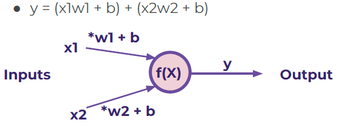

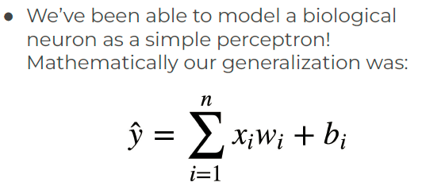

- Later on we will see how we can expand this model to have X be a **tensor of information (an n-dimensional matrix)**.
- Terminology:
  - Input Layer: First layer that directly accepts real data values
  - Hidden Layer: Any layer between input and output layers
  - Output Layer: The final estimate of the output.
- Neural Networks become “deep neural networks” if then contain 2 or more hidden layers.

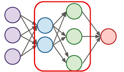

## “Universal Approximation Theorem”

- What is incredible about the neural network framework is that it can be used to approximate any function.
- Zhou Lu and later on Boris Hanin proved mathematically that Neural Networks can approximate any convex continuous function.

## Activation Functions

(https://en.wikipedia.org/wiki/Activation_function)

### * Sigmoid function

```
* Outputs between 0 to 1
```

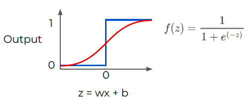

### * Hyperbolic Tangent: tanh(z)

```
* Outputs between -1 and 1 instead of 0 to 1
```

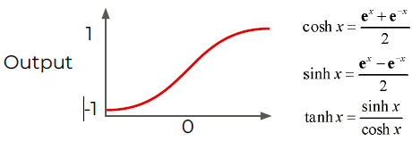

### * Rectified Linear Unit (ReLU)

```
* This is actually a relatively simple function: max(0,z)
```

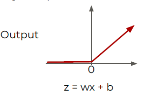

## Multi-Class Activation Functions

- There are 2 main types of multi-class situations
  - Non-Exclusive Classes
    - A data point can have multiple classes/categories assigned to it

    (Tags on photos)
  - Mutually Exclusive Classes
    - Only one class per data point.

    (Photo color can be grayscale (black and white) or full color

photos - not be both at the same time.)

### Organizing for Multiple Classes (1 output node per class)

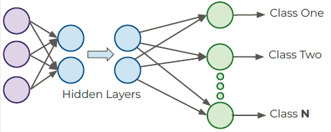

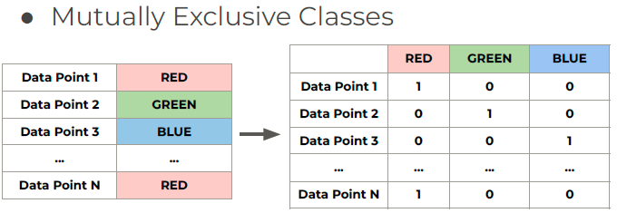

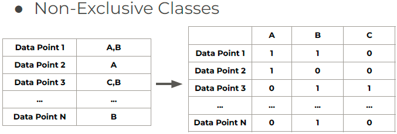

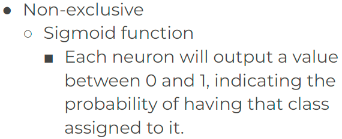

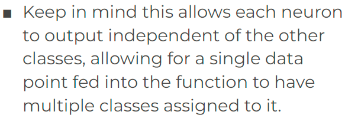

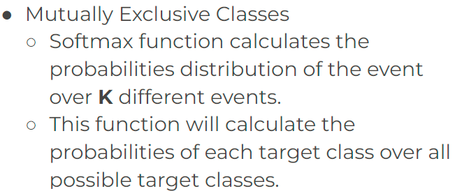

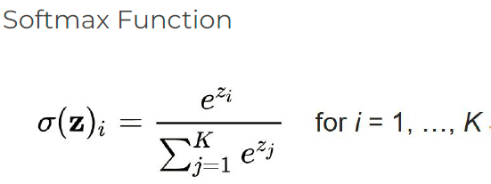

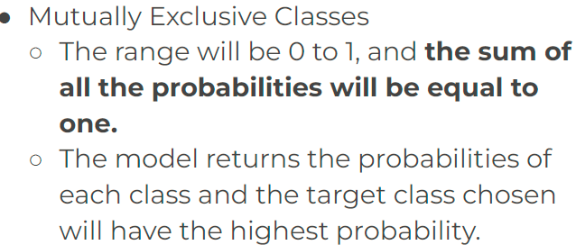

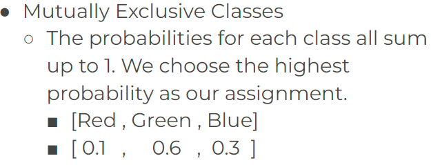

## Cost Functions and Gradient Descent

- The cost function (often referred to as a loss function) must be an average so it can output a single value.
- We can keep track of our loss/cost during training to monitor network performance.
- We’ll use the following variables:
  - y to represent the true value
  - a to represent neuron’s prediction
- In terms of weights and bias:
  - w*x + b = z
  - Pass z into activation function σ(z) = a [σ includes Weights, and biases]

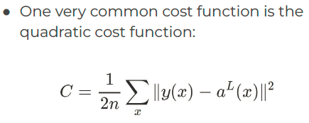

We simply calculate the difference between the real values y(x) against our predicted values a(x).

L represents the last Layer (L-1 = layer before)

So $$a^L(x)$$ represents the predicted output

Notice : squaring keeps everything positive and punishes large errors!

### Cost function can be represented like

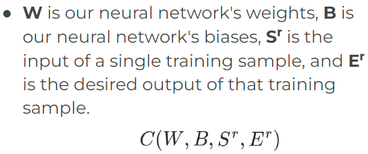

What we want is to minimize this cost function

Let's take the simple example of a Cost function depending of only 1 Weight

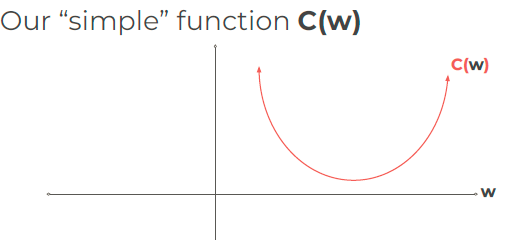

We can use the slope at a point and move in the downward direction of the slope

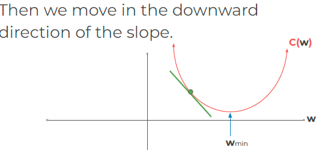

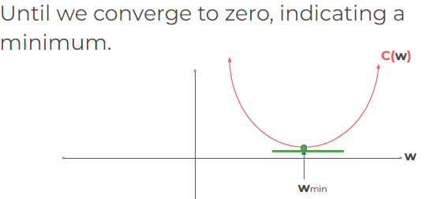

### Size of the step is important - This step size is known as the learning rate.

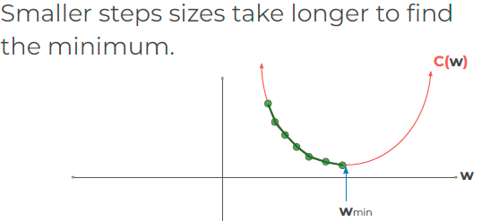

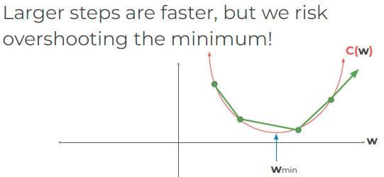

### Instead of having always same step size, we can have larger steps at the beginning and then go smaller as we realize the slope gets closer to zero.

### This is known as adaptive gradient descent.

"Adam: A Method for Stochastic Optimization" is a much more efficient way of searching for these minimums

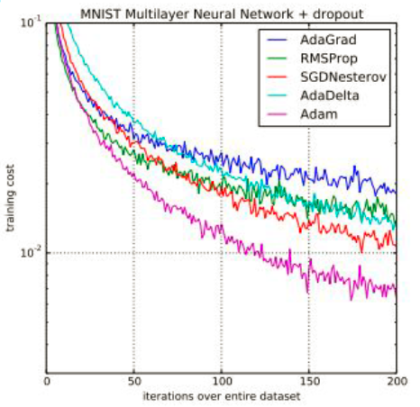

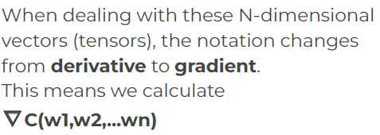

- **For classification problems, we often use the cross entropy loss function.**
- **The assumption is that your model predicts a probability distribution p(y=i) for each class i=1,2,…,C.**

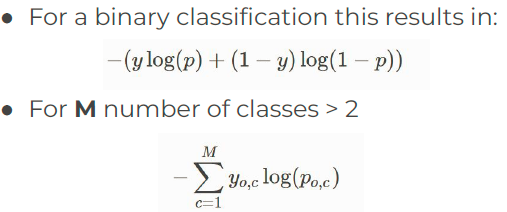

## Backpropagation

#### Let’s begin with a very simple network, where each layer only has 1 neuron

#### Each input will receive a weight and bias

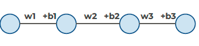

- This means we have cost function depending of all weights and biases: C(w1,b1,w2,b2,w3,b3)